# Confidence in the Press and Political Polarization

Author

Ari Gelbard

This document aims to answer the question how has trust in the press changed over time? And are there significant differences between different demographic groups or political ideologies?

# Loading Packages and Data

```r
### Load packages
library(tidyverse)
library(readxl)
library(zoo)
library(boot)

### Load data
gss_raw <- read_excel("data/gss_press.xlsx")
```

# Cleaning Data

```r
gss <- gss_raw %>%
  mutate(conpress = ifelse(conpress %in% c("ONLY SOME",
                                           "HARDLY ANY",
                                           "A GREAT DEAL"),
                           conpress,NA),
         polviews = ifelse(polviews %in% c(".i:  Inapplicable",
                                           ".d:  Do not Know/Cannot Choose",
                                           ".n:  No answer",
                                           ".s:  Skipped on Web"),
                           NA, polviews),
         age = ifelse(age %in% c(".n:  No answer",
                                 ".d:  Do not Know/Cannot Choose",
                                 ".i:  Inapplicable"),
                      NA, age),
         race = ifelse(race == ".i:  Inapplicable", NA, race),
         income = ifelse(income %in% c(".i:  Inapplicable",
                                       ".d:  Do not Know/Cannot Choose",
                                       ".r:  Refused",
                                       ".n:  No answer",
                                       ".s:  Skipped on Web"),
                         NA, income),
         year = as.numeric(year),
         id_ = as.numeric(id_)) %>%
  select(-partyid)
```

# Data Analysis

In this section, I want to explore the GSS variables we have to see if we can observe any interesting trends.

## Press Confidence

Our confidence in the press variables is conpress, which asked the respondent whether have a great deal of confidence, only some confidence, or hardly any confidence in the press? Lets plot it over time to see how opinions have evolved.

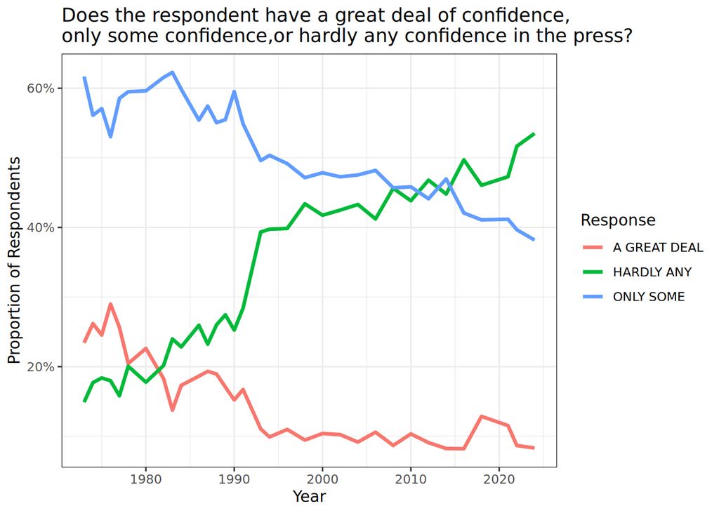

```r
# Get counts and proportion for each answer per years
conpress <- gss %>%
  group_by(year,conpress) %>%
  summarise(n = n(), .groups="drop") %>%
  group_by(year) %>%
  drop_na() %>%
  mutate(prop = n / sum(n))

ggplot(conpress, aes(x = year, y = prop, color = conpress)) +
  geom_line(linewidth = 1.2) +
  scale_y_continuous(labels = scales::percent) +
  labs(
    title = "Does the respondent have a great deal of confidence,
only some confidence,or hardly any confidence in the press?",
    x = "Year",
    y = "Proportion of Respondents",
    color = "Response"
  ) +
  theme_bw()
```

It seems pretty evident that confidence in the press has decreased significantly over time. In fact, the majority of respondents in 2024 have hardly any confidence in the press.

## Demographic Characteristics

Now let’s briefly look at how different demographic groups feel about the press.

```r
# Mutate data for plotting
gss_dem <- gss %>%
  filter(!is.na(conpress)) %>%
  mutate(conpress_num = case_when(
    conpress == "HARDLY ANY" ~ 1,
    conpress == "ONLY SOME" ~ 2,
    conpress == "A GREAT DEAL" ~ 3
  ),
  age = ifelse(age == "89 or older", 89, as.numeric(age)),
  age_group = case_when(
    age < 30 ~ "<30",
    age < 45 ~ "30-44",
    age < 60 ~ "45-59",
    TRUE     ~ "60+"
  ))
```

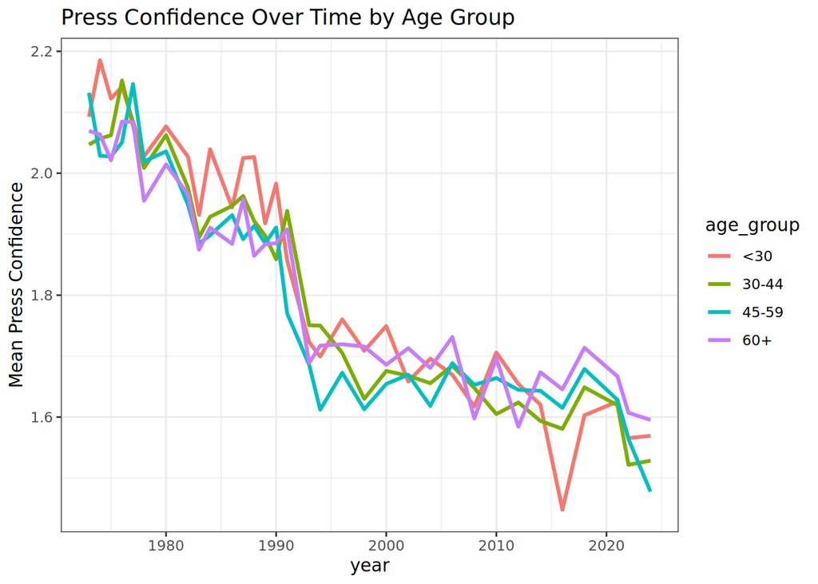

```r
# Mean confidence by age group
gss_dem %>%
  group_by(year, age_group) %>%
  summarise(mean_conf = mean(conpress_num, na.rm=TRUE)) %>%
  ggplot(aes(x=year, y=mean_conf, color=age_group)) +
  geom_line(linewidth=1.1) +
  labs(title="Press Confidence Over Time by Age Group",
       y="Mean Press Confidence") +
  theme_bw()
```

Evidently, confidence in the press is decreasing for all age groups, but are there significant differences between age groups?

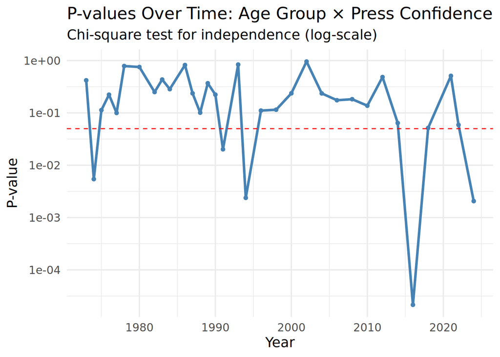

```r
age_diff_by_year <- gss_dem %>%
  filter(!is.na(age_group), !is.na(conpress)) %>%
  group_by(year) %>%
  summarise(
    chisq = list(chisq.test(table(age_group, conpress))),
    statistic = chisq[[1]]$statistic,
    p_value   = chisq[[1]]$p.value,
    df        = chisq[[1]]$parameter,
    .groups = "drop"
  )

ggplot(age_diff_by_year, aes(x = year, y = p_value)) +
  geom_line(color = "steelblue", linewidth = 1.2) +
  geom_point(color = "steelblue", size = 1.5) +
  geom_hline(yintercept = 0.05, color = "red", linetype = "dashed") +
  scale_y_continuous(trans = "log10") +
  labs(
    title = "P-values Over Time: Age Group × Press Confidence",
    subtitle = "Chi-square test for independence (log-scale)",
    x = "Year",
    y = "P-value"
  ) +
  theme_minimal(base_size = 14)
```

Since the p-values are fairly sporadic and mostly above 0.05, we can say that there is little evidence that confidence in the press varies by age group.

What about race?

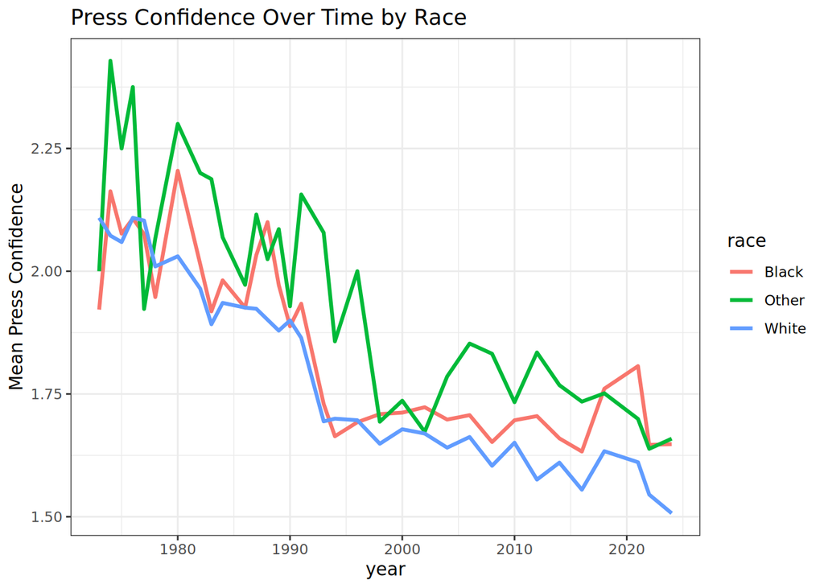

```r
# Mean confidence by race
gss_dem %>%
  group_by(year, race) %>%
  summarise(mean_conf = mean(conpress_num, na.rm=TRUE)) %>%
  filter(!is.na(race)) %>%
  ggplot(aes(x = year, y = mean_conf, color = race)) +
  geom_line(linewidth=1.1) +
  labs(title="Press Confidence Over Time by Race",
       y="Mean Press Confidence") +
  theme_bw()
```

We see a similar trend as in age, although other races may trust the press slightly more than white or black respondents.

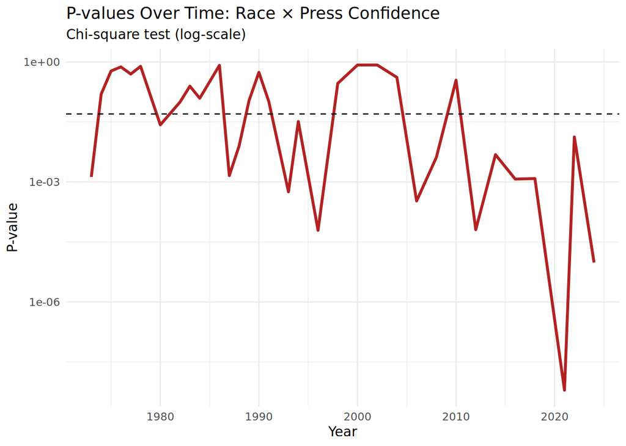

```r
race_by_year <- gss_dem %>%
  filter(!is.na(race), !is.na(conpress)) %>%
  group_by(year) %>%
  summarise(
    chisq     = list(chisq.test(table(race, conpress))),
    statistic = chisq[[1]]$statistic,
    p_value   = chisq[[1]]$p.value,
    df        = chisq[[1]]$parameter,
    .groups   = "drop"
  )
ggplot(race_by_year, aes(x = year, y = p_value)) +
  geom_line(color = "firebrick", linewidth = 1.1) +
  geom_hline(yintercept = 0.05, linetype = "dashed") +
  scale_y_continuous(trans = "log10") +
  labs(
    title = "P-values Over Time: Race × Press Confidence",
    subtitle = "Chi-square test (log-scale)",
    x = "Year",
    y = "P-value"
  ) +
  theme_minimal()
```

Again, we see sporadic p-values over time. More of them are below 0.05, however the volatility implies that there still aren’t significant differences betwee races.

Now we can look at income.

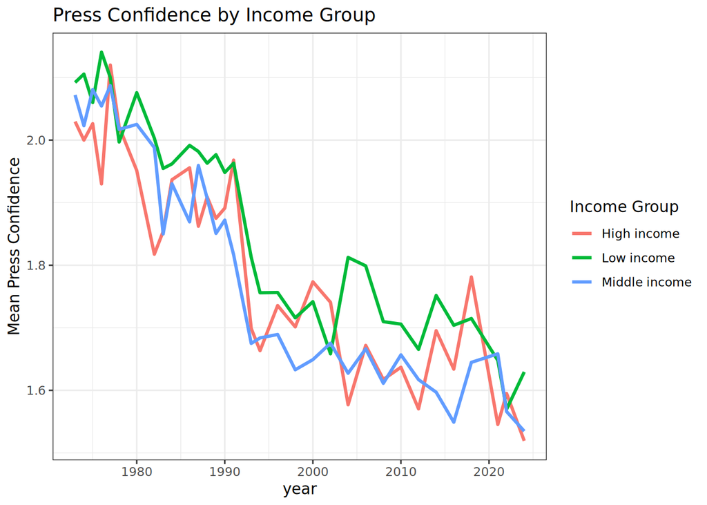

```r
# Mean confidence by income group
gss_dem <- gss_dem %>%
  mutate(
    income_clean = as.numeric(str_remove_all(str_extract(income, "\\$?\\d+,?\\d*"), "[$,]")),
    income_group = case_when(
      income_clean < 20000 ~ "Low income",
      income_clean < 50000 ~ "Middle income",
      TRUE                 ~ "High income"
    )
  )


gss_dem %>%
  group_by(year, income_group) %>%
  summarise(mean_conf = mean(conpress_num, na.rm = TRUE)) %>%
  ggplot(aes(x = year, y = mean_conf, color = income_group)) +
  geom_line(linewidth=1.1) +
  labs(title="Press Confidence by Income Group",
       y="Mean Press Confidence",
       color="Income Group") +
  theme_bw()
```

Again, we see decreases in confidence across the board.

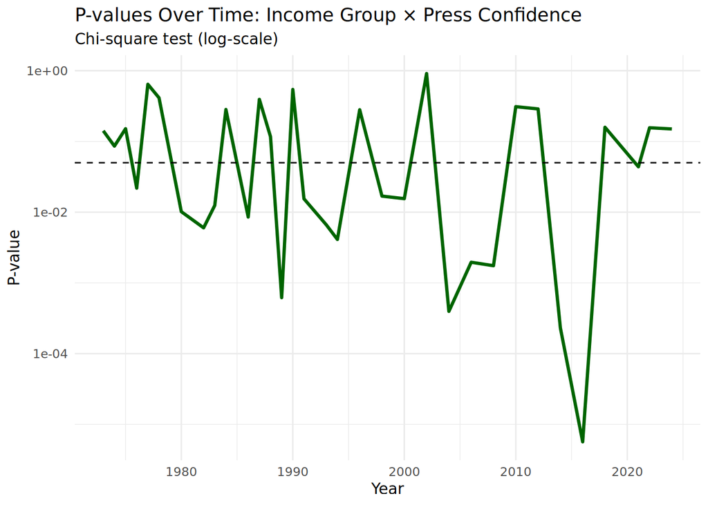

```r
income_by_year <- gss_dem %>%
  filter(!is.na(income_group), !is.na(conpress)) %>%
  group_by(year) %>%
  summarise(
    chisq     = list(chisq.test(table(income_group, conpress))),
    statistic = chisq[[1]]$statistic,
    p_value   = chisq[[1]]$p.value,
    df        = chisq[[1]]$parameter,
    .groups   = "drop"
  )

ggplot(income_by_year, aes(x = year, y = p_value)) +
  geom_line(color = "darkgreen", linewidth = 1.1) +
  geom_hline(yintercept = 0.05, linetype = "dashed") +
  scale_y_continuous(trans = "log10") +
  labs(
    title = "P-values Over Time: Income Group × Press Confidence",
    subtitle = "Chi-square test (log-scale)",
    x = "Year",
    y = "P-value"
  ) +
  theme_minimal()
```

We also see similar results from the chi-squared tests, implying that there aren’t significant differences between income groups in confidence in the press over time.

Finally, we can test the dependence of the demographic variables with confidence in the press with chi-squared tests. This will just confirm whether these demographic variables are dependent with press, not if there are differences between groups. The hypotheses are as follows:

$H_0:$ The distributions for the demographic characteristic and confidence in the press **are** independent.

$H_a:$ The distributions for the demographic characteristic and confidence in the press **are not** independent.

```r
# Chi-square: age_group vs conpress, year by year
age_tab <- table(gss_dem$age_group, gss_dem$conpress)
chisq.test(age_tab)
```

```
    Pearson's Chi-squared test

data:  age_tab
X-squared = 123.16, df = 6, p-value < 2.2e-16
```

```r
# Chi-square: race vs conpress, year by year
race_tab <- table(gss_dem$race, gss_dem$conpress)
chisq.test(race_tab)
```

```
    Pearson's Chi-squared test

data:  race_tab
X-squared = 19.71, df = 4, p-value = 0.0005697
```

```r
# Chi-square: income_group vs conpress, year by year
income_tab <- table(gss_dem$income_group, gss_dem$conpress)
chisq.test(income_tab)
```

```
    Pearson's Chi-squared test

data:  income_tab
X-squared = 1197.6, df = 4, p-value < 2.2e-16
```

All tests show p-values less than 0.05 meaning we reject the null hypothesis at the 5% level. In other words, we have enough statistical evidence to conclude that age, race, and income are not independent from confidence in the press.

## Political Polarization

- polviews: On a 7 point scale between extremely liberal and extremely conservative, where would you place yourself on this scale?

Let’s look at political views over time since this corresponds more closely to people’s beliefs than simple party identification.

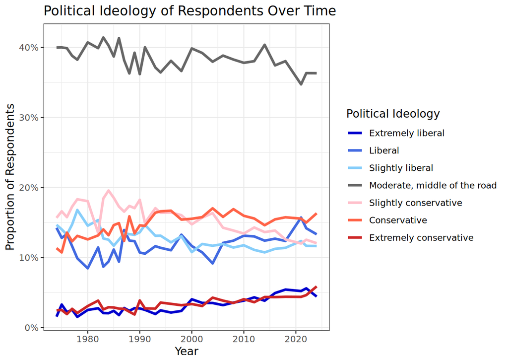

```r
polviews <- gss %>%
  mutate(polviews = factor(polviews,
                           levels = c("Extremely liberal",
                                      "Liberal",
                                      "Slightly liberal",
                                      "Moderate, middle of the road",
                                      "Slightly conservative",
                                      "Conservative",
                                      "Extremely conservative"))) %>%
  group_by(year,polviews) %>%
  summarise(n = n(), .groups="drop") %>%
  group_by(year) %>%
  drop_na() %>%
  mutate(prop = n / sum(n))

ggplot(polviews, aes(x = year, y = prop, color = polviews)) +
  geom_line(linewidth = 1.2) +
  scale_y_continuous(labels = scales::percent) +
  scale_color_manual(name = "Political Ideology",
                     values = c("Extremely liberal" = "blue3",
                                "Liberal" = "royalblue",
                                "Slightly liberal" = "lightskyblue",
                                "Moderate, middle of the road" = "gray40",
                                "Slightly conservative" = "pink",
                                "Conservative" = "tomato",
                                "Extremely conservative" = "firebrick3")) +
  labs(
    title = "Political Ideology of Respondents Over Time",
    x = "Year",
    y = "Proportion of Respondents",
    color = "Political Ideology"
  ) +
  theme_bw()
```

Most categories appear to have remained fairly stagnant. However there does seem to be a slight increase in the proportion of people who consider themselves extremely liberal and extremely conservative from about 2% to about 5% for both categories. We can see this trend more concretely if we look at the standard deviation of responses. We can do this by converting them back into numerical variables that range from 1 to 7, and then calculating the standard deviation in each year and plotting it.

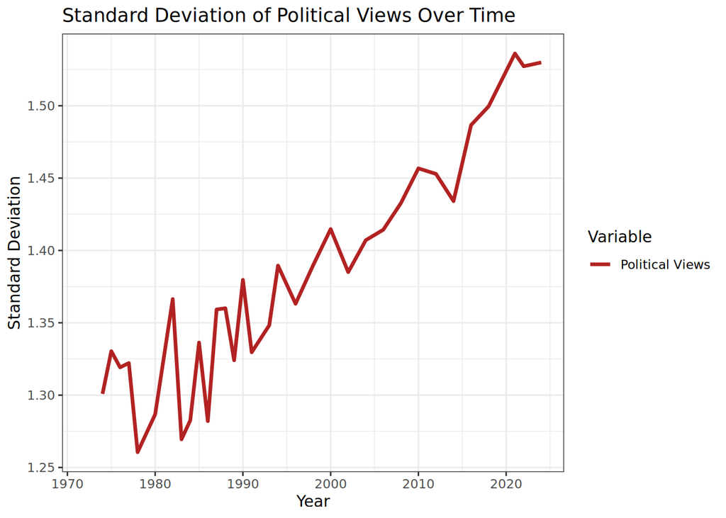

```r
gss <- gss %>%
  mutate(polviews_num = ifelse(polviews == "Extremely liberal", 1,
                               ifelse(polviews == "Liberal", 2,
                                      ifelse(polviews == "Slightly liberal", 3,
                                             ifelse(polviews == "Moderate, middle of the road", 4,
                                                    ifelse(polviews == "Slightly conservative", 5,
                                                           ifelse(polviews == "Conservative", 6,
                                                                  ifelse(polviews == "Extremely conservative", 7, NA))))))))

spread_by_year <- gss %>%
  group_by(year) %>%
  summarise(
    sd_pol = sd(polviews_num, na.rm = TRUE),
    n = sum(!is.na(polviews_num))
  )

ggplot(data=spread_by_year,aes(x=year)) +
  geom_line(linewidth = 1.2, aes(y=sd_pol, color="Political Views")) +
  scale_color_manual(name = "Variable",
                     values = c("Political Views" = "firebrick")) +
  labs(title = "Standard Deviation of Political Views Over Time",
       x = "Year",
       y = "Standard Deviation") +
  theme_bw()
```

To test whether the standard deviation of political ideology has actually increased over time, we can do a bootstrapping test of the standard deviation trend. We can do this by estimating a bootstrapping standard deviation for the periods before and after 1998, and then we can take the difference of the resulting 95% confidence intervals to get an interval for the change.

```r
N <- 5000

# function to compute SD
boot_sd <- function(data, idx) {
  sd(data[idx], na.rm = TRUE)
}

early <- gss$polviews_num[gss$year < 1998]
late  <- gss$polviews_num[gss$year >= 1998]

boot_early <- boot(early, boot_sd, R = N)
boot_late  <- boot(late, boot_sd, R = N)

boot.ci(boot_late, type="perc")
```

```
BOOTSTRAP CONFIDENCE INTERVAL CALCULATIONS
Based on 5000 bootstrap replicates

CALL :
boot.ci(boot.out = boot_late, type = "perc")

Intervals :
Level     Percentile
95%   ( 1.455,  1.474 )
Calculations and Intervals on Original Scale
```

```r
boot.ci(boot_early, type="perc")
```

```
BOOTSTRAP CONFIDENCE INTERVAL CALCULATIONS
Based on 5000 bootstrap replicates

CALL :
boot.ci(boot.out = boot_early, type = "perc")

Intervals :
Level     Percentile
95%   ( 1.326,  1.346 )
Calculations and Intervals on Original Scale
```

```r
# Compare distributions or compute CI of difference
sd_diff <- boot_late$t - boot_early$t
quantile(sd_diff, c(.025, .975))
```

```
     2.5%     97.5%
0.1157107 0.1429977
```

Since the difference in the 95% bootstrap confidence interval is positive, we can conclude with 95% certainty that the standard deviation of political views increased by between 0.116 and 0.142 standard deviations.

Based on these results, we can confidently say that political polarization has increased over time.

## Media Confidence and Political Ideology

Now let’s investigate how political polarization and media confidence relate. First, we can just plot the standard deviation of political ideology from the previous section with mean press confidence over time.

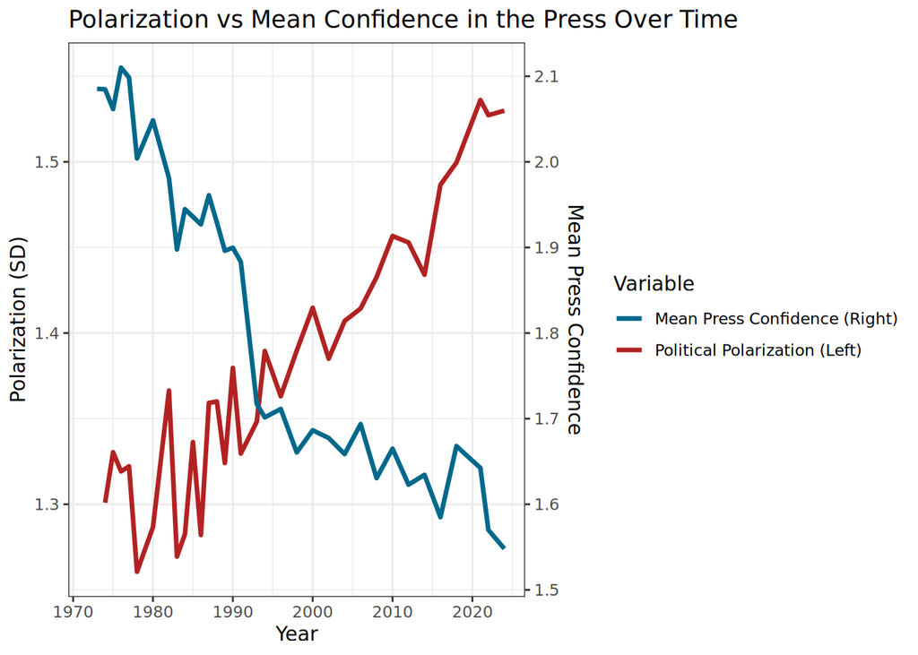

```r
press_pol <- gss %>%
  mutate(conpress_num = case_when(
    conpress == "HARDLY ANY" ~ 1,
    conpress == "ONLY SOME" ~ 2,
    conpress == "A GREAT DEAL" ~ 3)) %>%
  group_by(year) %>%
  summarise(mean_conf = mean(conpress_num, na.rm = TRUE)) %>%
  right_join(spread_by_year, by = "year") %>%
  arrange(year) %>%
  mutate(mean_conf = na.approx(mean_conf, x = year, na.rm = FALSE),
         sd_pol    = na.approx(sd_pol,    x = year, na.rm = FALSE))

ggplot(press_pol, aes(x = year)) +
  geom_line(aes(y = sd_pol, color = "Political Polarization (Left)"),
            linewidth=1.2) +
  geom_line(aes(y = 0.5 * mean_conf + 0.5, color = "Mean Press Confidence (Right)"),
            linewidth=1.2) +
  scale_y_continuous(name = "Polarization (SD)",
                     sec.axis = sec_axis(~ (. - .5) / .5,
                                         name = "Mean Press Confidence")) +
  scale_color_manual(values = c("Political Polarization (Left)" = "firebrick",
                                "Mean Press Confidence (Right)" = "deepskyblue4")) +
  labs(title="Polarization vs Mean Confidence in the Press Over Time",
       x="Year",
       color="Variable") +
  theme_bw()
```

Based on this chart, we can see more clearly that political polarization has been increasing while mean press confidence has been decreasing. But how has average confidence in the press evolved over time for different political ideologies?

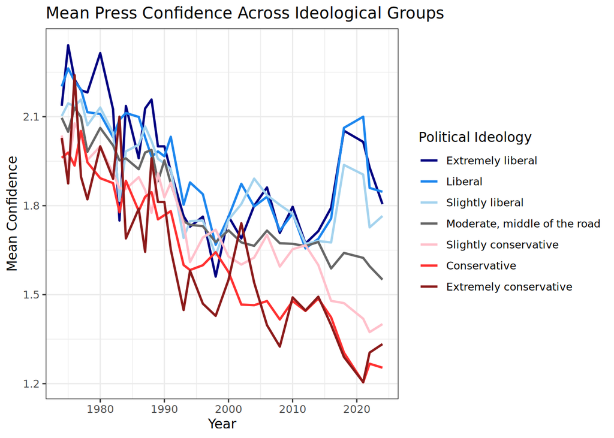

```r
mean_by_pol <- gss %>%
  mutate(conpress_num = case_when(
    conpress == "HARDLY ANY" ~ 1,
    conpress == "ONLY SOME" ~ 2,
    conpress == "A GREAT DEAL" ~ 3
  )) %>%
  mutate(polviews_cat = polviews) %>%
  group_by(year, polviews_cat) %>%
  summarise(mean_conf = mean(conpress_num, na.rm=TRUE), .groups="drop") %>%
  filter(!is.na(polviews_cat)) %>%
  group_by(polviews_cat) %>%
  arrange(year) %>%
  mutate(mean_conf = na.approx(mean_conf, x = year, na.rm = FALSE)) %>%
  ungroup() %>%
  mutate(polviews_cat = factor(polviews_cat,
                           levels = c("Extremely liberal",
                                      "Liberal",
                                      "Slightly liberal",
                                      "Moderate, middle of the road",
                                      "Slightly conservative",
                                      "Conservative",
                                      "Extremely conservative")))

ggplot(mean_by_pol, aes(x = year, y = mean_conf,
                        group = polviews_cat, color = polviews_cat)) +
  geom_line(linewidth = 0.9) +
  scale_color_manual(name = "Political Ideology",
                     values = c("Extremely liberal" = "navyblue",
                                "Liberal" = "dodgerblue2",
                                "Slightly liberal" = "lightskyblue2",
                                "Moderate, middle of the road" = "gray40",
                                "Slightly conservative" = "pink",
                                "Conservative" = "firebrick1",
                                "Extremely conservative" = "firebrick4")) +
  labs(
    title = "Mean Press Confidence Across Ideological Groups",
    x = "Year",
    y = "Mean Confidence",
    color = "Political Ideology"
  ) +
  theme_bw()
```

All ideologies seem to have been loosing confidence in the press over time. There was a large spike in the late 2010s among liberals, but their confidence has still decreased over all and appears like it may continue to decrease.

We can test whether the distributions for political identification and confidence in the press are independent using a Chi-Squared test for independence. The null and alternative hypotheses for this test are as follows

$H_0:$ The distributions for political views and confidence in the press **are** independent.

$H_a:$ The distributions for political views and confidence in the press **are not** independent.

```r
chisq.test(table(gss$polviews, gss$conpress))
```

```
    Pearson's Chi-squared test

data:  table(gss$polviews, gss$conpress)
X-squared = 1551.1, df = 12, p-value < 2.2e-16
```

The resulting p-value is less than 0.05 which means that we can reject the null hypothesis at the 5% level. In other words, we have sufficient statistical evidence to conclude that the distributions of political views and confidence in the press are not independent.

We can also check if the dependence has increased over time by rerunning the Chi-Squared test for every year and plotting the results.

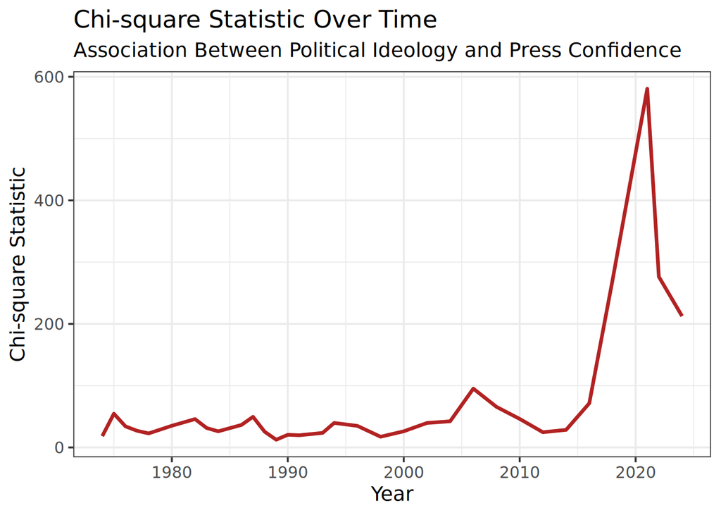

```r
gss_chisq <- gss %>%
  filter(!is.na(polviews), !is.na(conpress)) %>%
  mutate(polviews = factor(polviews),
         conpress = factor(conpress))

chi_by_year <- gss_chisq %>%
  group_by(year) %>%
  summarise(
    chisq = list(chisq.test(table(polviews, conpress)))
  ) %>%
  mutate(
    statistic = map_dbl(chisq, "statistic"),
    p_value   = map_dbl(chisq, "p.value"),
    df        = map_dbl(chisq, ~ .x$parameter)
  )

ggplot(chi_by_year, aes(x = year, y = statistic)) +
  geom_line(linewidth = 1.2, color = "firebrick") +
  labs(
    title = "Chi-square Statistic Over Time",
    subtitle = "Association Between Political Ideology and Press Confidence",
    x = "Year",
    y = "Chi-square Statistic"
  ) +
  theme_bw(base_size = 14)
```

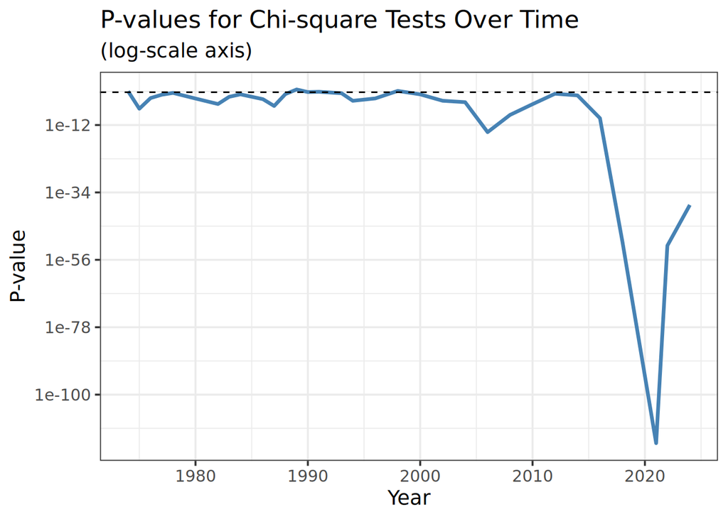

```r
ggplot(chi_by_year, aes(x = year, y = p_value)) +
  geom_line(linewidth = 1.2, color = "steelblue") +
  geom_hline(yintercept = 0.05, linetype = "dashed") +
  scale_y_continuous(trans = "log10") +
  labs(
    title = "P-values for Chi-square Tests Over Time",
    subtitle = "(log-scale axis)",
    x = "Year",
    y = "P-value"
  ) +
  theme_bw(base_size = 14)
```

We can see from the p-value plot that most p-values are below the 5% level. This means that we can reject the null hypothesis at the 5% level for most years in the sample. Furthermore, there is a large spike after 2016, which corresponds with the beginning of President Trump’s first term. This all indicates that there are significant differences in confidence in press between ideological groups. It appears that liberals tend to trust the press more than conservatives.

Finally, let’s quickly test if political polarization relates to confidence in the press with a pearson correlation test. The hypotheses are:

$H_0: \rho = 0$ i.e. there is no linear relationship between political polarization and press confidence.

$H_a: \rho \neq 0$ i.e. there is a linear relationship between political polarization and press confidence.

```r
ideol_press <- gss %>%
  mutate(conpress_num = case_when(
    conpress == "HARDLY ANY" ~ 1,
    conpress == "ONLY SOME" ~ 2,
    conpress == "A GREAT DEAL" ~ 3
  )) %>%
  group_by(year) %>%
  summarise(
    mean_conf = mean(conpress_num, na.rm=TRUE),
    sd_pol    = sd(polviews_num, na.rm=TRUE)
  ) %>%
  arrange(year)

cor.test(ideol_press$sd_pol, ideol_press$mean_conf)
```

```
    Pearson's product-moment correlation

data:  ideol_press$sd_pol and ideol_press$mean_conf
t = -7.9844, df = 30, p-value = 6.523e-09
alternative hypothesis: true correlation is not equal to 0
95 percent confidence interval:
 -0.9112856 -0.6680109
sample estimates:
       cor
-0.8246241
```

The p-value of the test is less than 0.05 meaning we can reject the null hypothesis. In other words, there is sufficient statistical evidence to conclude that political polarization and press confidence have a linear relationship.

# Conclusion

Confidence in the press has clearly decreased over the past 50 years across all groups, regardless of age, race, income, or political ideology. We discovered that liberals tend to trust the press more, but their trust has also been decreasing. Furthermore, although we cannot confidently say that increased political polarization is a cause of or a result of a decrease in press confidence over time, we can say with certainty that the two are closely related and have been covarying, particularly in the past few years.